# Final Project - Intro to Statistics and Data Analysis

Tomer Blum 208947382 and Noa Shapira 319121166

June 2021

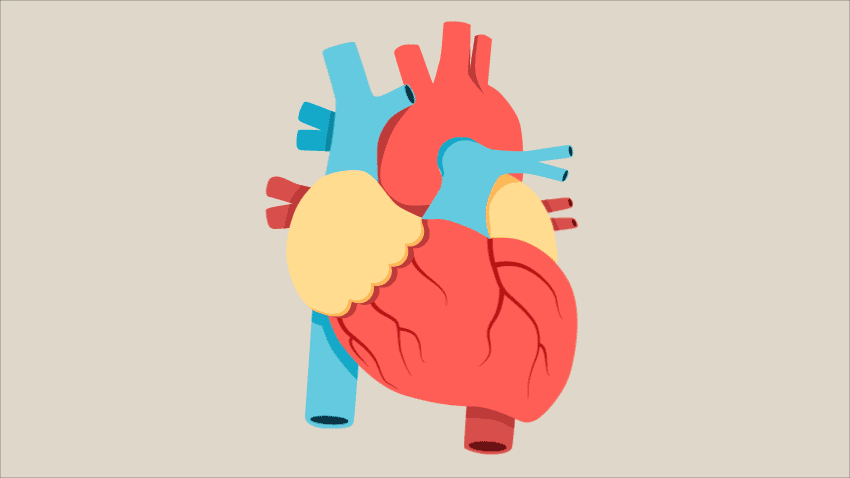

## Introduction

In this project we analyzed a data set containing 13 features and 300 samples regarding heart attack probability.  
We will use different methods we learned in the course by examining the relations between different features from the data set.  
The goal of our project is to demonstrate and practice the different elements we have learned.

**Variables we focused on:**  
1. Chest pain  
2. Maximum heart rate  
3. The slope of the peak exercise ST segment  
4. ST depression induced by exercise relative to rest  
5. diagnosis of heart disease (angiographic disease status) in any major vessel  
6. Gender of the person

**Methods we used:**  
1. Multiple linear regression.  
2. Hypothesis test: F-test for variances and T-test for means.

## Data Import

First, we read the heart attack file

```r
heart_attack <- read.csv("heart.csv")
```

## Data Tidying

Now, we will get a glimpse of the data set

```r
glimpse(heart_attack)
```

```
## Rows: 303
## Columns: 14
## $ age      <int> 63, 37, 41, 56, 57, 57, 56, 44, 52, 57, 54, 48, 49, 64, 58, 5~
## $ sex      <int> 1, 1, 0, 1, 0, 1, 0, 1, 1, 1, 1, 0, 1, 1, 0, 0, 0, 0, 1, 0, 1~
## $ cp       <int> 3, 2, 1, 1, 0, 0, 1, 1, 2, 2, 0, 2, 1, 3, 3, 2, 2, 3, 0, 3, 0~
## $ trtbps   <int> 145, 130, 130, 120, 120, 140, 140, 120, 172, 150, 140, 130, 1~
## $ chol     <int> 233, 250, 204, 236, 354, 192, 294, 263, 199, 168, 239, 275, 2~
## $ fbs      <int> 1, 0, 0, 0, 0, 0, 0, 0, 1, 0, 0, 0, 0, 0, 1, 0, 0, 0, 0, 0, 0~
## $ restecg  <int> 0, 1, 0, 1, 1, 1, 0, 1, 1, 1, 1, 1, 1, 0, 0, 1, 1, 1, 1, 1, 1~
## $ thalachh <int> 150, 187, 172, 178, 163, 148, 153, 173, 162, 174, 160, 139, 1~
## $ exng     <int> 0, 0, 0, 0, 1, 0, 0, 0, 0, 0, 0, 0, 0, 1, 0, 0, 0, 0, 0, 0, 0~
## $ oldpeak  <dbl> 2.3, 3.5, 1.4, 0.8, 0.6, 0.4, 1.3, 0.0, 0.5, 1.6, 1.2, 0.2, 0~
## $ slp      <int> 0, 0, 2, 2, 2, 1, 1, 2, 2, 2, 2, 2, 2, 1, 2, 1, 2, 0, 2, 2, 1~
## $ caa      <int> 0, 0, 0, 0, 0, 0, 0, 0, 0, 0, 0, 0, 0, 0, 0, 0, 0, 0, 0, 2, 0~
## $ thall    <int> 1, 2, 2, 2, 2, 1, 2, 3, 3, 2, 2, 2, 2, 2, 2, 2, 2, 2, 2, 2, 3~
## $ output   <int> 1, 1, 1, 1, 1, 1, 1, 1, 1, 1, 1, 1, 1, 1, 1, 1, 1, 1, 1, 1, 1~
```

We would like our data to be unique, so we will remove identical rows

```r
get_duplicates <- function(df){
    total_rows = dim(df)[1]
    unique_rows = dim(df %>% group_by_all %>% count)[1]
    n_duplicates = (total_rows - unique_rows)
    cat('n duplicates -> ', n_duplicates)
}

get_duplicates(heart_attack)
```

```
## n duplicates ->  1
```

```r
heart_attack = unique(heart_attack)
get_duplicates(heart_attack)
```

```
## n duplicates ->  0
```

## Variable Description

[output not shown]

We will check if there are NaN values in our data set

```r
colSums(is.na(heart_attack))
```

```
##      age      sex       cp   trtbps     chol      fbs  restecg thalachh
##        0        0        0        0        0        0        0        0
##     exng  oldpeak      slp      caa    thall   output
##        0        0        0        0        0        0
```

As we see above, there are no NaN values.

## Transforming variables

Our data including only numerical values, so currently, we won’t need any further pre-processing. We believe that some of the values are categorical, where each number presents different category. In the visualization step, we will try to verify our assumption by plotting each feature and seeing it’s distribution.

## Visualizing

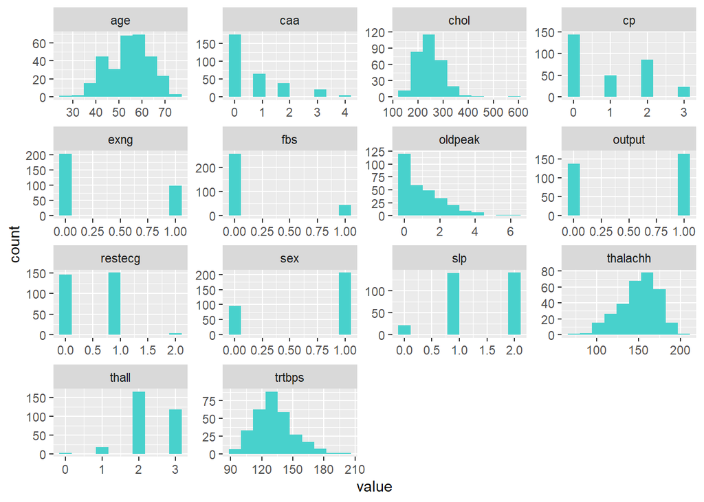

```r
ggplot(gather(heart_attack), aes(value)) + geom_histogram(bins = 10, fill = "mediumturquoise") + facet_wrap(~key, scales = 'free', ncol = 4)
```

Now, we can clearly see the difference between categorical features and numerical ones:  
**Numerical Features:** `age`, `chol`, `oldpeak`, `thalachh` and `trtbps`.  
**Categorical Features:** `caa`, `cp`, `exng`, `fbs`, `restecg`, `sex`, `slp`,`output` and `thall`.

We can see that `age`, `chol`, `thalachh` and `trtbps` seem to distribute normally, in order to assure that we will plot QQplot graphs. If a variable distributes normally, we will see diagonal line.

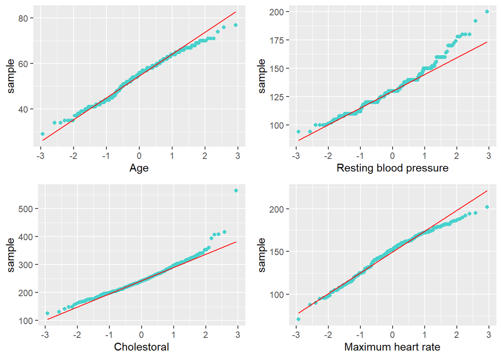

```r
age_qq <- ggplot(heart_attack, aes(sample = age)) + geom_qq(color = "mediumturquoise") + geom_qq_line(col = "red") + labs(x = "Age")
trtbps_qq <- ggplot(heart_attack, aes(sample = trtbps)) + geom_qq(color = "mediumturquoise") + geom_qq_line(col = "red") + labs(x = "Resting blood pressure")
chol_qq <- ggplot(heart_attack, aes(sample = chol)) + geom_qq(color = "mediumturquoise") + geom_qq_line(col = "red") + labs(x = "Cholestoral")
thalachh_qq <- ggplot(heart_attack, aes(sample = thalachh)) + geom_qq(color = "mediumturquoise") + geom_qq_line(col = "red") + labs(x = "Maximum heart rate")

grid.arrange(age_qq, trtbps_qq, chol_qq, thalachh_qq, ncol = 2)
```

All the features except Resting blood pressure (trtbps) appear to distribute normally.

Now we will plot pie chart for the features `heart_attack` and `gender`

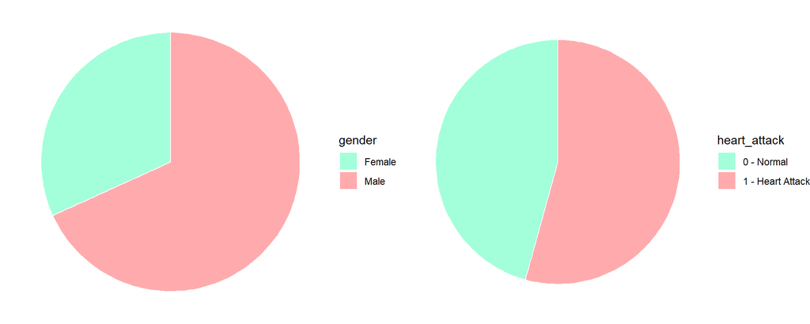

```r
make_string = function(bool_var){
  char_list = c(1, length(bool_var))
  for (i in 1:length(bool_var)) {
    var = bool_var[i]
    new_char = 'unknown'

    if(var == 1){
        new_char = 'Male'
    }
    else{
        new_char = 'Female'
     }

     char_list[i] =  new_char
   }

    return(char_list)
 }

gender_df <- heart_attack %>%
    select(sex) %>%
    group_by(sex) %>%
    summarise(Count = n()) %>%
    arrange(desc(Count)) %>%
    mutate(
        gender = make_string(sex),
        percentage = paste0(round(Count / sum(Count) * 100, 1), "%")
    )

plot01 <- ggplot(gender_df, aes(x = "", y = Count, fill = gender )) + geom_bar(stat="identity", width=1, color="white") +  coord_polar("y", start=0) + theme_void() + scale_fill_manual(values=c("#A2FFDA", "#FFABAD"))
make_string_heart = function(bool_var){
  char_list = c(1, length(bool_var))
  for (i in 1:length(bool_var)) {
    var = bool_var[i]
    new_char = 'unknown'

    if(var == 0){
        new_char = '0 - Normal'
     }

    if(var == 1){
        new_char = '1 - Heart Attack'
    }

     char_list[i] =  new_char
   }

    return(char_list)
 }

output_df <- heart_attack %>%
    select(output) %>%
    group_by(output) %>%
    summarise(Count = n()) %>%
    arrange(desc(Count)) %>%
    mutate(
        heart_attack = make_string_heart(output),
        percentage = paste0(round(Count / sum(Count) * 100, 1), "%")
    )

plot02 <- ggplot(output_df, aes(x = "", y = Count, fill = heart_attack )) + geom_bar(stat="identity", width=1, color="white") +  coord_polar("y", start=0) + theme_void() + scale_fill_manual(values=c("#A2FFDA", "#FFABAD"))
grid.arrange(plot01, plot02, ncol = 2)
```

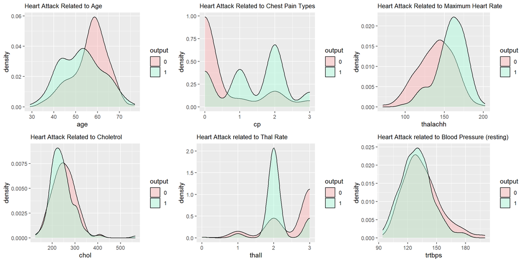

```r
heart_attack_mod <- heart_attack %>%
  mutate(output = as.factor(output))

plot1 <- ggplot(heart_attack_mod,aes(x = age, fill = output)) + geom_density(alpha = 0.4) + ggtitle("Heart Attack Related to Age") + theme(plot.title = element_text(size = 10) ) + scale_fill_manual(values=c("#FFABAD","#A2FFDA"))
plot2 <-ggplot(heart_attack_mod,aes(x = cp, fill = output)) + geom_density(alpha = 0.4) + ggtitle("Heart Attack Related to Chest Pain Types") + theme(plot.title = element_text(size = 10) ) + scale_fill_manual(values=c("#FFABAD","#A2FFDA"))
plot3 <-ggplot(heart_attack_mod,aes(x = thalachh, fill = output)) + geom_density(alpha = 0.4) + ggtitle("Heart Attack Related to Maximum Heart Rate") + theme(plot.title = element_text(size = 10) ) + scale_fill_manual(values=c("#FFABAD","#A2FFDA"))
plot4 <-ggplot(heart_attack_mod,aes(x = chol, fill = output)) + geom_density(alpha = 0.4) + ggtitle("Heart Attack Related to Choletrol") + theme(plot.title = element_text(size = 10) ) + scale_fill_manual(values=c("#FFABAD","#A2FFDA"))
plot5 <-ggplot(heart_attack_mod,aes(x = thall, fill = output)) + geom_density(alpha = 0.4) + ggtitle("Heart Attack related to Thal Rate") + theme(plot.title = element_text(size = 10) ) + scale_fill_manual(values=c("#FFABAD","#A2FFDA"))
plot6 <-ggplot(heart_attack_mod,aes(x = trtbps, fill = output)) + geom_density(alpha = 0.4) + ggtitle("Heart Attack related to Blood Pressure (resting)") + theme(plot.title = element_text(size = 10) ) + scale_fill_manual(values=c("#FFABAD","#A2FFDA"))

grid.arrange(plot1, plot2, plot3, plot4, plot5, plot6, ncol = 3)
```

```r
heart_attack %>%
  filter(output == 1, sex == 0) %>%
  summarise(
    min = min(age),
    median = median(age),
    mean = mean(age),
    max = max(age)
  )
```

```
##   min median     mean max
## 1  34     54 54.55556  76
```

From the information above, we learn that for women in the dataset the minimal age for heart attack risk is 34, the maximal age is 76, the median age is 54 and the mean age is 54.5.

```r
heart_attack %>%
  filter(output == 1, sex == 1) %>%
  summarise(
    min = min(age),
    median = median(age),
    mean = mean(age),
    max = max(age)
  )
```

```
##   min median     mean max
## 1  29     52 51.04348  70
```

From the information above, we learn that for men in the dataset the minimal age for heart attack risk is 29, the maximal age is 70, the median age is 52 and the mean age is 51.04.

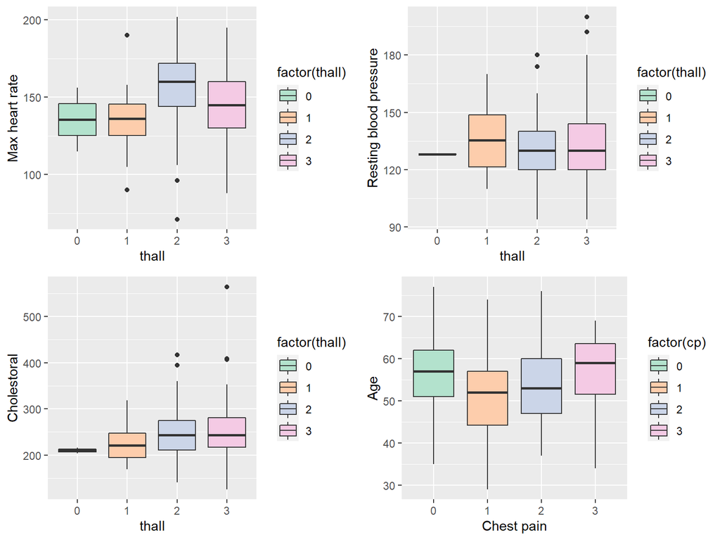

```r
p1 <-ggplot(heart_attack, aes(x = factor(thall), y = thalachh, fill = factor(thall))) + geom_boxplot() + scale_fill_brewer(palette = "Pastel2") + xlab("thall") + ylab("Max heart rate")
p2 <- ggplot(heart_attack, aes(x = factor(thall), y = trtbps, fill = factor(thall))) + geom_boxplot() + xlab("thall") + ylab("Resting blood pressure") + scale_fill_brewer(palette = "Pastel2")
p3 <- ggplot(heart_attack, aes(x = factor(thall), y = chol, fill = factor(thall))) + geom_boxplot() + xlab("thall") + ylab("Cholestoral") + scale_fill_brewer(palette = "Pastel2")
p4 <- ggplot(heart_attack, aes(x = factor(cp), y = age, fill = factor(cp))) + geom_boxplot() + xlab("Chest pain") + ylab("Age") + scale_fill_brewer(palette = "Pastel2")
grid.arrange(p1,p2,p3,p4,ncol = 2)
```

**Conclusions from the boxplots above:**  
-There are outliers in the categorical data.  
-We can see that people with Thallium Stress Test Value of 2 have higher Max Heart Rates.  
-Some people with Thallium Stress Test Value of 1 have higher Resting Blood Pressure.  
-People with Thallium Stress Test with values of 2 and 3 tend to have higher cholestoral levels.  
-People older than 50 years tend to have Anginal Pains.

In order to see the differences in maximum heart rate between males and females, we will plot histograms for each one of them.

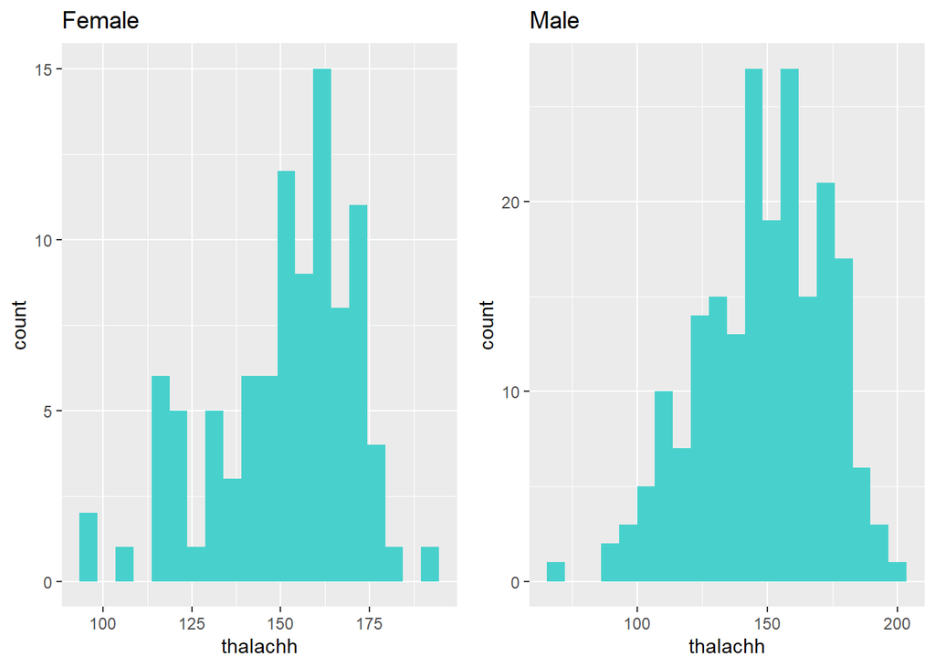

```r
female_thalachh <- heart_attack %>%
  filter(sex == 0) %>%
  select(thalachh)
pl01 <- ggplot(female_thalachh, aes(thalachh)) + geom_histogram(bins = 20, fill = "mediumturquoise") + ggtitle("Female")

male_thalachh <- heart_attack %>%
  filter(sex == 1) %>%
  select(thalachh)
pl02 <- ggplot(male_thalachh, aes(thalachh)) + geom_histogram(bins = 20, fill = "mediumturquoise") + ggtitle("Male")
grid.arrange(pl01, pl02, ncol = 2)
```

We can see that the two plots aren’t identical, but seem similar and share the same peak.  
In addition, we can see that the distributions are pretty normal.

## Modeling

### 1. Multi Linear Regression

We will check the correlation between different features using a hitmap:

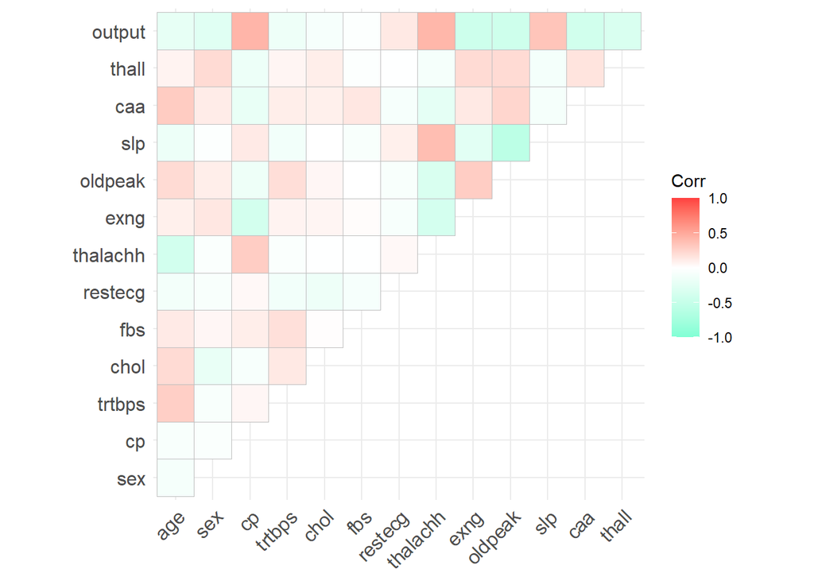

```r
heart_attack_corr <- cor(heart_attack)
ggcorrplot(heart_attack_corr, type = 'upper', hc.method = 'complete', colors = c("aquamarine", "white", "brown1") )
```

We see some positive correlation between `cp` & `output`, `thalachh` & `output` and `thalachh` & `slp`.  
we also see negative correlation between `oldpeak` & `slp`.

Building a multiple regression model with the variables: `output` in relation to `thalachh`, `slp`, `oldpeak` and `cp`

```r
multi_regression <- lm(output~thalachh + slp + oldpeak + cp,data = heart_attack)
summary(multi_regression)
```

```
##
## Call:
## lm(formula = output ~ thalachh + slp + oldpeak + cp, data = heart_attack)
##
## Residuals:
##     Min      1Q  Median      3Q     Max
## -0.9806 -0.2795  0.0487  0.2925  0.8651
##
## Coefficients:
##              Estimate Std. Error t value Pr(>|t|)
## (Intercept) -0.235312   0.175863  -1.338 0.181905
## thalachh     0.004464   0.001143   3.904 0.000117 ***
## slp          0.057849   0.047196   1.226 0.221284
## oldpeak     -0.116133   0.024633  -4.715 3.73e-06 ***
## cp           0.156627   0.023393   6.695 1.07e-10 ***
## ---
## Signif. codes:  0 '***' 0.001 '**' 0.01 '*' 0.05 '.' 0.1 ' ' 1
##
## Residual standard error: 0.3998 on 297 degrees of freedom
## Multiple R-squared:  0.3666, Adjusted R-squared:  0.3581
## F-statistic: 42.98 on 4 and 297 DF,  p-value: < 2.2e-16
```

$Y = -0.235 +0.004X_{1} +0.057X_{2} -0.116X_{3} +0.156X_{4}$

After looking at the model summary, we can see in the residuals section that the median equals to 0.048, which is close to the mean (0), it might help us later.  
In addition, we can see that the adjusted R squared is pretty low, which means the explained variance percentage is low, and our model doesn’t fit to the data.

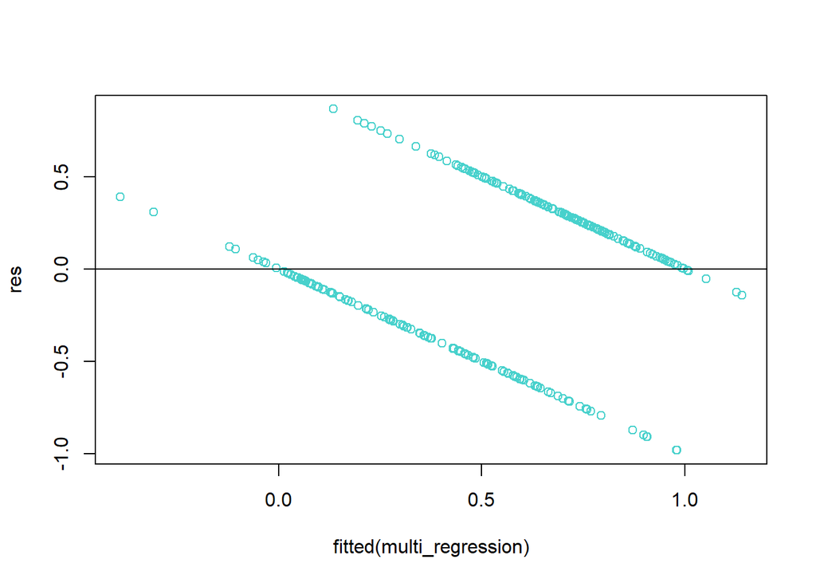

```r
res <- resid(multi_regression)
plot(fitted(multi_regression), res, col = "mediumturquoise")
abline(0,0)
```

The x-axis displays the fitted values and the y-axis displays the residuals. From the plot we can see that the spread of the residuals tends to be heteroscedastic.

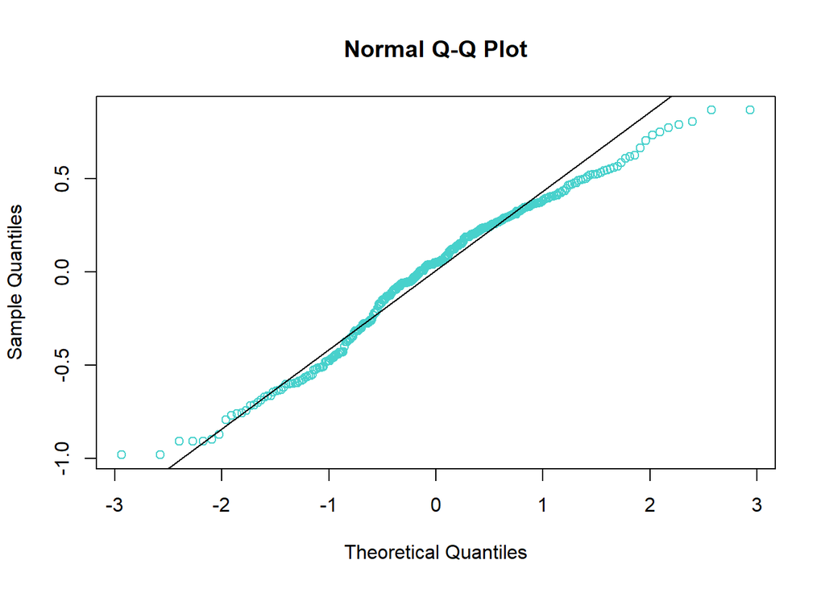

```r
qqnorm(res, col = "mediumturquoise")
qqline(res)
```

The residuals tend to stray from the line quite a bit near the tails, which could indicate that they are not normally distributed.

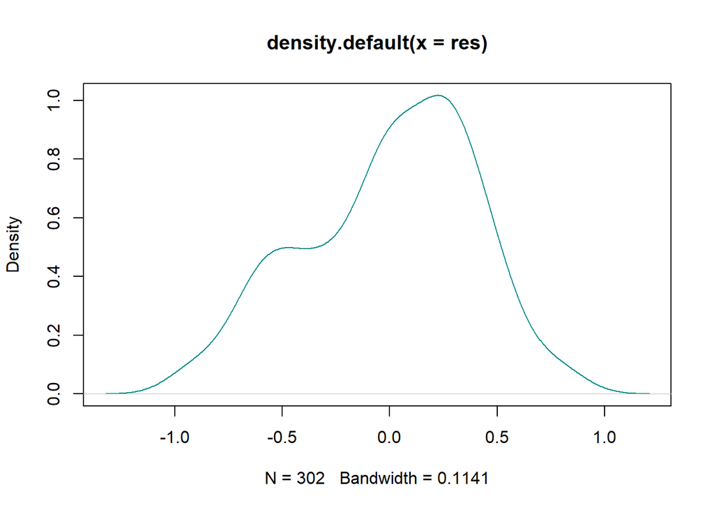

```r
plot(density(res), col = "darkcyan")
```

From the density residuals plot we can see that the residuals doesn’t normally distributed.

**Conclusions:**  
- The residuals first plot shows us that the residuals are heteroscedastic.  
- The QQ and density plots shows that the residuals aren’t normally distributed.  
**To summarize, given the low R-squared, heteroscedastic residuals and the problematic distribution of the residuals, we think the model is unsuitable for the data.**

### 2. Hypothesis test

We will use T-test to check if the mean of the maximum heart rate is equal between male and female. In order to do so, we will first need to check if the variance is equal, using F-test.

First, we will plot boxplots of each group (females and males)

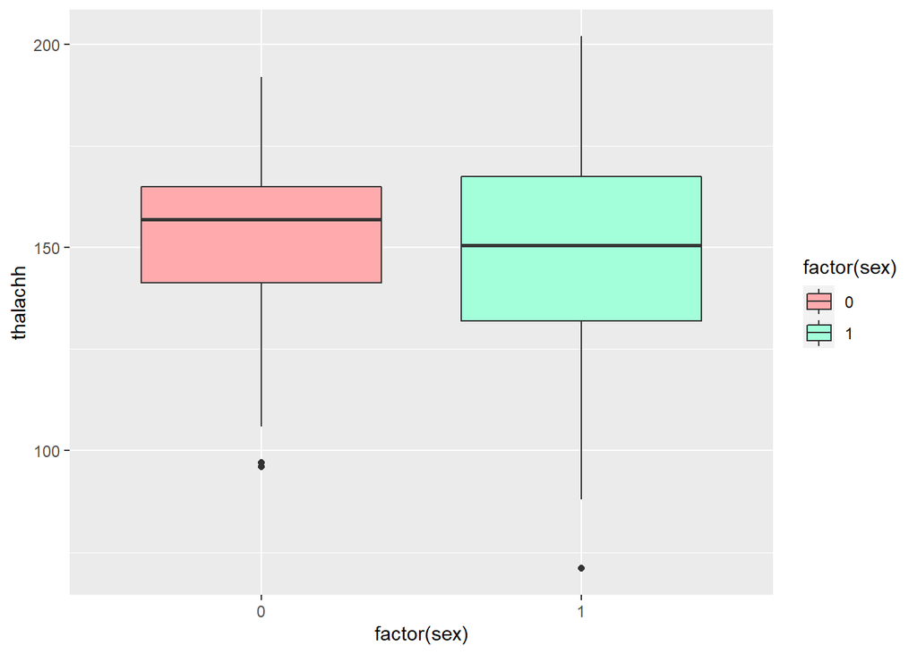

```r
ggplot(heart_attack, aes(x = factor(sex), y = thalachh, fill = factor(sex))) + geom_boxplot() + scale_fill_manual(values=c("#FFABAD","#A2FFDA"))
```

**Assumptions:**  
-The two samples are independent.  
-From the boxplots we can see that the male group distributes normally.  
-We will assume normality on the female distribution group.

**Hypothesis:**  
$H_{0}: \sigma_{m}^{2} = \sigma_{f}^{2}$  
$H_{1}: \sigma_{m}^{2} \not= \sigma_{f}^{2}$

```r
var.test(formula = thalachh ~ factor(sex), data = heart_attack)
```

```
##
##  F test to compare two variances
##
## data:  thalachh by factor(sex)
## F = 0.69022, num df = 95, denom df = 205, p-value = 0.0418
## alternative hypothesis: true ratio of variances is not equal to 1
## 95 percent confidence interval:
##  0.4939374 0.9861196
## sample estimates:
## ratio of variances
##          0.6902214
```

Since our p value is smaller then 5% we reject the null hypothesis, the variances are unequal.

**Assumptions:**  
-The two samples are independent.  
-From the boxplots we can see that the male group distributes normally.  
-We will assume normality on the female distribution group.  
-The variances are unequal.

**Hypothesis:**  
$H_{0}: \mu_{m} = \mu_{f}$  
$H_{1}: \mu_{m} \not= \mu_{f}$

```r
t.test(formula = thalachh ~ sex, data = heart_attack, alternative = "two.sided")
```

```
##
##  Welch Two Sample t-test
##
## data:  thalachh by sex
## t = 0.86106, df = 220.09, p-value = 0.3901
## alternative hypothesis: true difference in means is not equal to 0
## 95 percent confidence interval:
##  -2.938902  7.499582
## sample estimates:
## mean in group 0 mean in group 1
##        151.1250        148.8447
```

## Conclusions:

In this project we used different methods to manipulate the format data and to visualize the different data set features using:  
boxplots, qqplots, density plots, piecharts. By that, we assumed different hypotheses about our data, explored the effect of gender on different aspects and tested relations between the different variables.  
To summarize, this project gave us a great opportunity to practice coding, gain experience in data analysis and implement methods we’ve learned during the course.